# Assignment3

crator-creator/20162306임유석

2021 4 14

### Climate change Dataset

##1. Climate Change

#### 1-1. 데이터 특성 분석

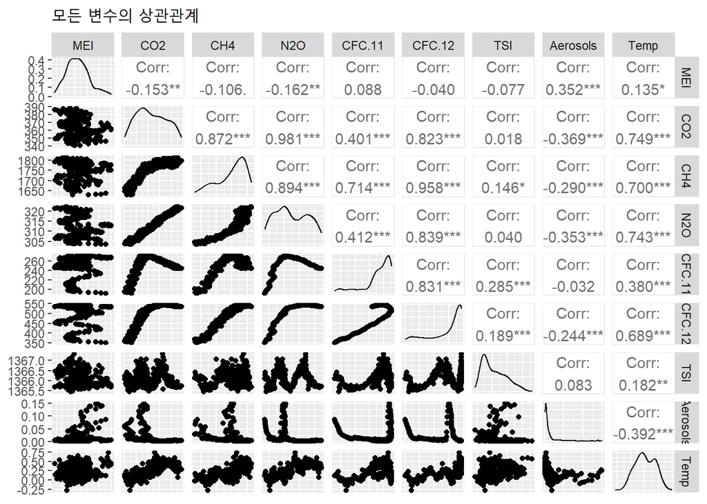

```r
# 사용할 패키지 추가
library(ggplot2)
library(GGally)
library(psych)
library(caret)
library(glmnet)
climate = read.csv('ClimateChange.csv')[,c(-1,-2)]
#모든 변수의 산점도
ggpairs(climate[c(1:9)],title="모든 변수의 상관관계")+theme(axis.title.x=element_blank(),axis.text.x=element_blank(),axis.ticks.x=element_blank())
```

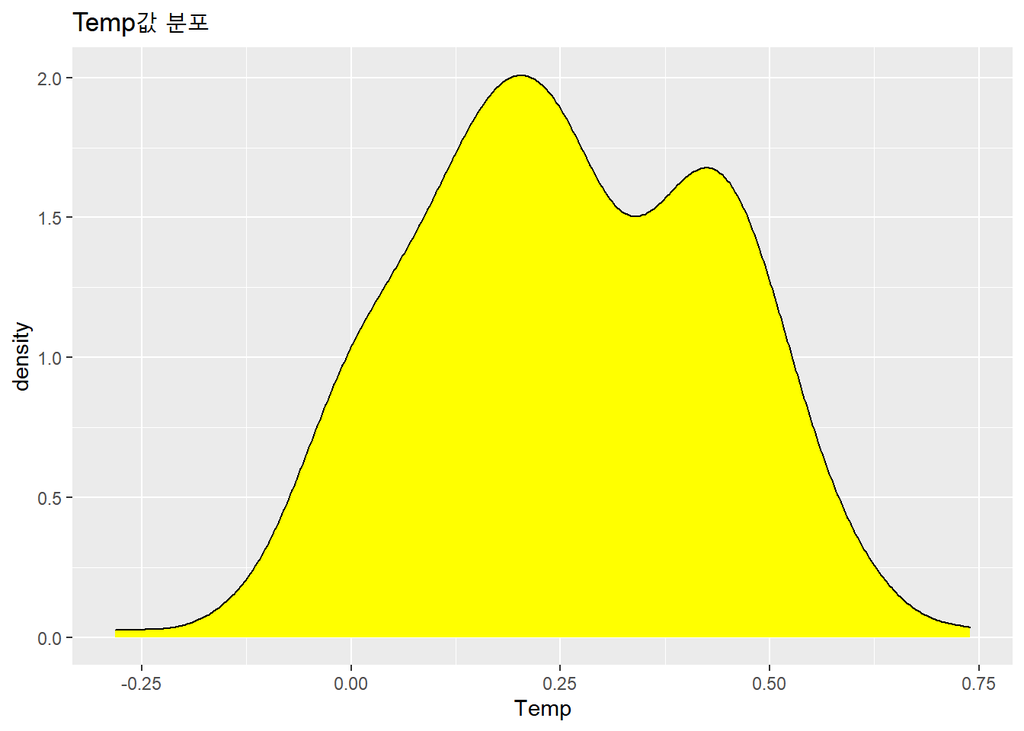

```
모두 연속형 변수이므로 산점도와 커널밀도그래프를 작성하였다.
- CO2, CH4, N20, CFC.11, CFC.12와 같은 기체들은 대체적으로 강한 선형관계를 가진다
- Temp와 대부분의 변수는 높은 양의 상관관계를 보여주지만 Aerosols은 음의 상관관계를 보인다.
- TSI와 CFC계열 프레온 가스는 타 변수의 비해 상관정도가 높다.
- 수집기간중 Temp의 온도는 약0.25 인 경우가 가장 많았다.
```

```r
#temp 값 분포 파악
ggplot(climate, aes(x=Temp))+geom_density(fill="yellow")+ggtitle("Temp값 분포")
```

#### 1-2. 2004년 이후의 데이터를 test set으로 2003년까지의 데이터를 training set으로 분할하자. 그리고 training set을 활용하여 linear regression model을 수립하자. 이때 8개의 feature변수를 모두 포함시킨다

```r
climate = read.csv('ClimateChange.csv')
#2003년을 기준으로 dataset 분리
tr=climate$Year <= 2003
tr1=climate$Year > 2003
climate_train = climate[tr,][,c(-1,-2)]
climate_test = climate[tr1,][,c(-1,-2)]
rownames(climate_test)=c(1:60)
#모든 feature를 반영한 회귀모델구성
model1 = lm(Temp ~., data=climate_train )
summary(model1)
```

```
##
## Call:
## lm(formula = Temp ~ ., data = climate_train)
##
## Residuals:
##      Min       1Q   Median       3Q      Max
## -0.25789 -0.06259 -0.00590  0.05567  0.32702
##
## Coefficients:
##               Estimate Std. Error t value Pr(>|t|)
## (Intercept) -1.385e+02  2.333e+01  -5.939 1.00e-08 ***
## MEI          6.528e-02  6.870e-03   9.501  < 2e-16 ***
## CO2          6.632e-03  2.643e-03   2.509 0.012768 *
## CH4          2.013e-04  5.939e-04   0.339 0.734969
## N2O         -2.525e-02  1.092e-02  -2.312 0.021635 *
## CFC.11      -7.666e-03  1.972e-03  -3.887 0.000131 ***
## CFC.12       4.557e-03  1.267e-03   3.598 0.000390 ***
## TSI          1.051e-01  1.792e-02   5.866 1.48e-08 ***
## Aerosols    -1.590e+00  2.269e-01  -7.010 2.42e-11 ***
## ---
## Signif. codes:  0 '***' 0.001 '**' 0.01 '*' 0.05 '.' 0.1 ' ' 1
##
## Residual standard error: 0.09482 on 239 degrees of freedom
## Multiple R-squared:  0.7133, Adjusted R-squared:  0.7037
## F-statistic: 74.32 on 8 and 239 DF,  p-value: < 2.2e-16
```

[output not shown]

#### 1-3. MEI,TSI,Aerosols,N20 feature을 이용한 regression model

```r
#4개의 feature로 구성된 회귀모델 구성
model2 = lm(Temp ~ MEI+TSI+Aerosols+N2O, data=climate_train )
summary(model2)
```

```
##
## Call:
## lm(formula = Temp ~ MEI + TSI + Aerosols + N2O, data = climate_train)
##
## Residuals:
##      Min       1Q   Median       3Q      Max
## -0.27840 -0.05990 -0.00633  0.05624  0.34294
##
## Coefficients:
##               Estimate Std. Error t value Pr(>|t|)
## (Intercept) -1.169e+02  2.315e+01  -5.052 8.58e-07 ***
## MEI          6.492e-02  7.089e-03   9.158  < 2e-16 ***
## TSI          8.003e-02  1.712e-02   4.674 4.89e-06 ***
## Aerosols    -1.708e+00  2.290e-01  -7.459 1.54e-12 ***
## N2O          2.524e-02  1.811e-03  13.933  < 2e-16 ***
## ---
## Signif. codes:  0 '***' 0.001 '**' 0.01 '*' 0.05 '.' 0.1 ' ' 1
##
## Residual standard error: 0.09935 on 243 degrees of freedom
## Multiple R-squared:  0.6799, Adjusted R-squared:  0.6747
## F-statistic: 129.1 on 4 and 243 DF,  p-value: < 2.2e-16
```

```r
#test set에 대한 예측_model1
climate_test_pred = predict(model1, climate_test)
#RMSE
sqrt(mean((climate_test_pred - climate_test$Temp)^2))
```

```
## [1] 0.08439069
```

```r
#test set에 대한 예측_model2
climate_test_pred2 = predict(model2, climate_test)
#RMSE
sqrt(mean((climate_test_pred2 - climate_test$Temp)^2))
```

```
## [1] 0.08501107
```

[output not shown]

#### 1-4. 8개의 feature를 대상으로 cross validation을 활용한 stepwise variable selection을 수행해보자

```r
#forward selection
train.control <- trainControl(method = "repeatedcv", number = 10, repeats =10)
set.seed(123)
fwd_model <- train(Temp ~., data = climate_train, method = "leapForward",
tuneGrid = data.frame(nvmax = 1:8), trControl = train.control)
#forward selection 결과
fwd_model$results
```

```
##   nvmax       RMSE  Rsquared        MAE     RMSESD RsquaredSD      MAESD
## 1     1 0.11373609 0.5899044 0.09021887 0.01598520 0.09368043 0.01299704
## 2     2 0.10753581 0.6332606 0.08564431 0.01528940 0.09456430 0.01268594
## 3     3 0.10173722 0.6768066 0.08180641 0.01422864 0.08522643 0.01103330
## 4     4 0.09728482 0.7045826 0.07697140 0.01506197 0.08669919 0.01145288
## 5     5 0.09753415 0.7034327 0.07709461 0.01522140 0.08647759 0.01162503
## 6     6 0.09583757 0.7132613 0.07526793 0.01559147 0.08625654 0.01182718
## 7     7 0.09499867 0.7154413 0.07504331 0.01524956 0.08589050 0.01217697
## 8     8 0.09544338 0.7126878 0.07531706 0.01543442 0.08671072 0.01226267
```

```r
#best 모델
fwd_model$bestTune
```

```
##   nvmax
## 7     7
```

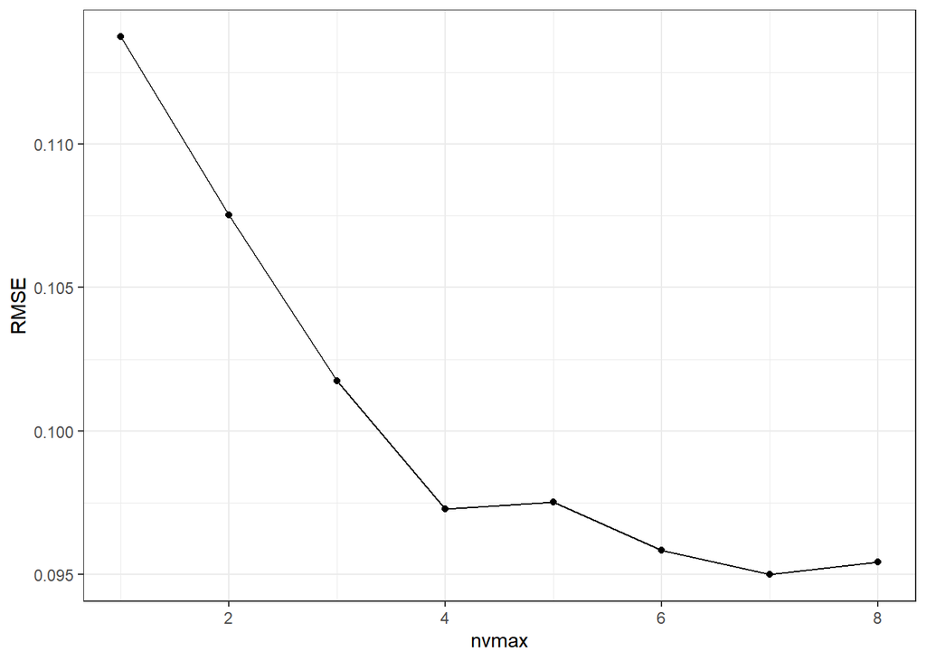

```r
#nvmax에 따른 RMSE변화 시각화
ggplot(fwd_model$results, aes(x=nvmax, y=RMSE)) + geom_point() + geom_line() + theme_bw()
```

```r
#bestmodel의 coefficient값 및 testset RMSE구하기
test.mat <- model.matrix(Temp~., data=climate_test)
coef_fwd_cv <- coef(fwd_model$finalModel, fwd_model$bestTune$nvmax)
test_pred_fwd_cv <- test.mat[, names(coef_fwd_cv)] %*% coef_fwd_cv
RMSE(test_pred_fwd_cv, climate_test$Temp)
```

```
## [1] 0.08359067
```

```r
#backward selection
set.seed(123)
bwd_model <- train(Temp ~., data = climate_train, method = "leapBackward",  tuneGrid = data.frame(nvmax = 1:8), trControl = train.control)
#backward selection 결과
bwd_model$results
```

```
##   nvmax       RMSE  Rsquared        MAE     RMSESD RsquaredSD      MAESD
## 1     1 0.13115162 0.4467842 0.10332523 0.01587955 0.11316815 0.01290413
## 2     2 0.11668908 0.5630856 0.09166896 0.01669367 0.09398085 0.01367106
## 3     3 0.10955651 0.6160419 0.08666421 0.01570641 0.09249453 0.01368154
## 4     4 0.10297559 0.6644236 0.08234794 0.01404487 0.08172937 0.01155344
## 5     5 0.09625674 0.7094548 0.07557908 0.01580171 0.08755498 0.01202552
## 6     6 0.09681709 0.7069208 0.07604616 0.01528315 0.08585382 0.01188464
## 7     7 0.09499867 0.7154413 0.07504331 0.01524956 0.08589050 0.01217697
## 8     8 0.09544338 0.7126878 0.07531706 0.01543442 0.08671072 0.01226267
```

```r
#best 모델
bwd_model$bestTune
```

```
##   nvmax
## 7     7
```

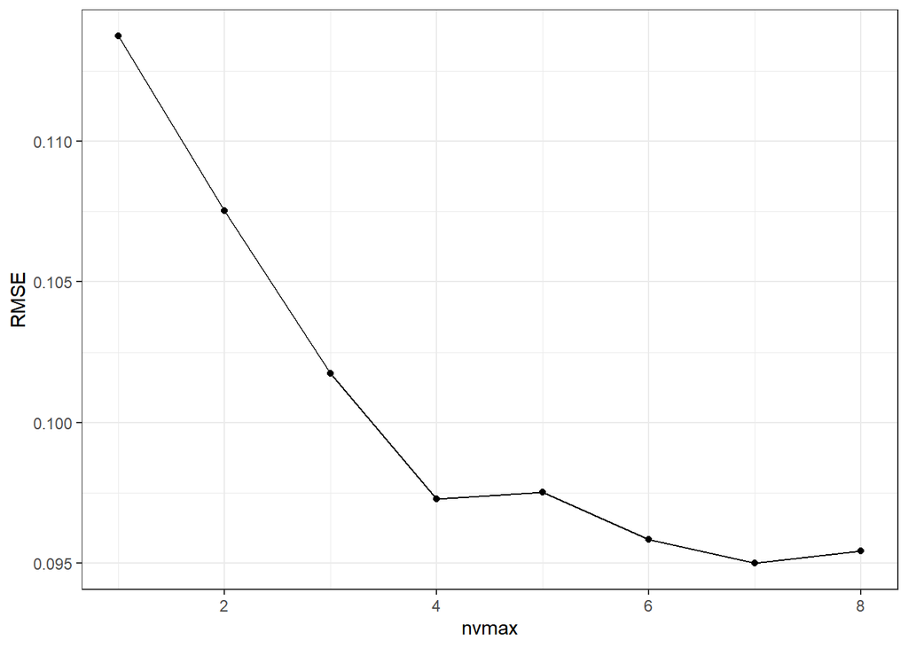

```r
#nvmax에 따른 RMSE변화 시각화
ggplot(fwd_model$results, aes(x=nvmax, y=RMSE)) + geom_point() + geom_line() + theme_bw()
```

```r
#bestmodel의 coefficient값 및 testset RMSE구하기
coef_bwd_cv <- coef(bwd_model$finalModel, bwd_model$bestTune$nvmax)
test_pred_bwd_cv <- test.mat[, names(coef_bwd_cv)] %*% coef_bwd_cv
RMSE(test_pred_bwd_cv, climate_test$Temp)
```

```
## [1] 0.08359067
```

```
(a)forward와 backward selection 모두 7개의 feature를 선택하였다.
(b)forward 모델과 backward모델의 최적의 feature갯수는 모두 7개로 나왔으며 coefficient값 또한 동일하다. 더불어 각 model의 rusults를 본 결과 R^2도 가장 높게 나타났다. 그래서 CH4를 제외한 feature 7개를 가지는 모델을 bset모델로 결정한다.(feature은 MEI/CO2/N2O/CFC.11/CFC.12/TSI/Aerosols 이다.)
```

#### 1-5. Prediction accuracy를 높이기 위해, 기존 8개의 feature들 외에 feature들 사이의 모든 interaction effect, 그리고 CO2, CFC.11, CFC.12의 제곱항들을 모두 추가한 모델을 대상으로 cross validation을 활용한 stepwise variable selection을 수행해보자.

```r
#forward selection
set.seed(123)
#모델 생성
fwd_model <- train(Temp~(.)^2+I(CO2^2)+I(CFC.11^2)+I(CFC.12^2), data = climate_train,
method = "leapForward", tuneGrid = data.frame(nvmax = 1:8), trControl =
trainControl(method="repeatedcv", number = 10, repeats = 5))
#결과확인
fwd_model$results
```

```
##   nvmax       RMSE  Rsquared        MAE     RMSESD RsquaredSD      MAESD
## 1     1 0.11391373 0.5888669 0.09043463 0.01600177 0.07980508 0.01301038
## 2     2 0.10733591 0.6332972 0.08575455 0.01619163 0.08744112 0.01318739
## 3     3 0.10048120 0.6841432 0.08116742 0.01562110 0.08452138 0.01225178
## 4     4 0.09686374 0.7050144 0.07725763 0.01655670 0.08951617 0.01363687
## 5     5 0.09563200 0.7133450 0.07600874 0.01588841 0.08617834 0.01319991
## 6     6 0.09381167 0.7228060 0.07430330 0.01604656 0.08953791 0.01339221
## 7     7 0.09355592 0.7233079 0.07385039 0.01584932 0.08563927 0.01280388
## 8     8 0.09117440 0.7371131 0.07165862 0.01568047 0.08040349 0.01279443
```

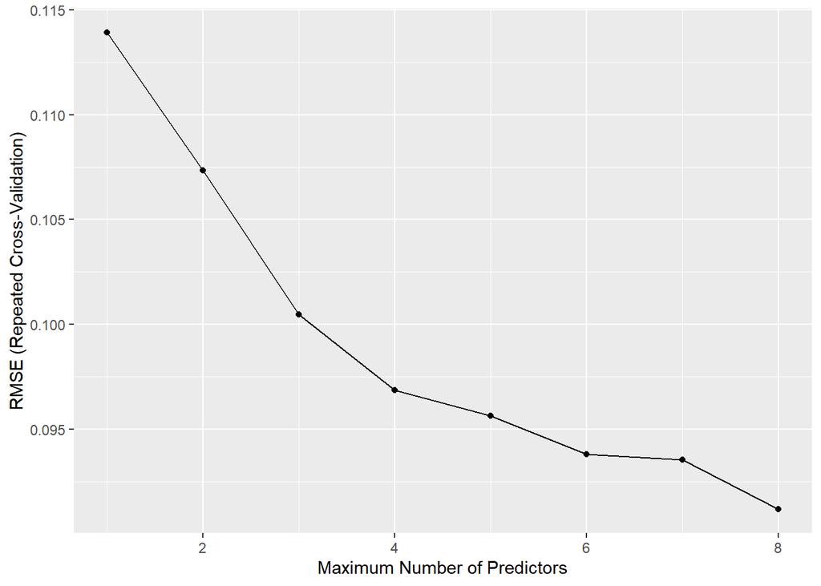

```r
#그래프 시각화
ggplot(fwd_model)
```

```r
#최적의 모델 coeff값
coef_fwd_cv <- coef(fwd_model$finalModel, 8)
#testset RMSE
test_pred_fwd <- predict(fwd_model, newdata=climate_test)
RMSE(test_pred_fwd, climate_test$Temp)
```

```
## [1] 0.08494405
```

```r
#backward selection
set.seed(123)
#모델 생성
bwd_model <- train(Temp~(.)^2+I(CO2^2)+I(CFC.11^2)+I(CFC.12^2), data = climate_train,
method = "leapBackward", tuneGrid = data.frame(nvmax = 1:8), trControl =
trainControl(method="repeatedcv", number = 10, repeats = 5))
#결과확인
bwd_model$results
```

```
##   nvmax       RMSE  Rsquared        MAE     RMSESD RsquaredSD      MAESD
## 1     1 0.13125765 0.4458752 0.10343957 0.01613691 0.09999349 0.01375298
## 2     2 0.11860230 0.5532065 0.09350733 0.01611472 0.08424145 0.01354410
## 3     3 0.11129866 0.6071414 0.08860355 0.01631278 0.09150610 0.01453876
## 4     4 0.10392228 0.6618165 0.08360050 0.01529589 0.08495502 0.01290235
## 5     5 0.09313941 0.7245887 0.07344564 0.01612055 0.08537789 0.01257689
## 6     6 0.09190459 0.7335184 0.07233312 0.01631547 0.08205752 0.01254871
## 7     7 0.09038030 0.7389921 0.07130304 0.01588934 0.08271383 0.01229751
## 8     8 0.08943588 0.7438747 0.07010238 0.01589705 0.08339877 0.01290467
```

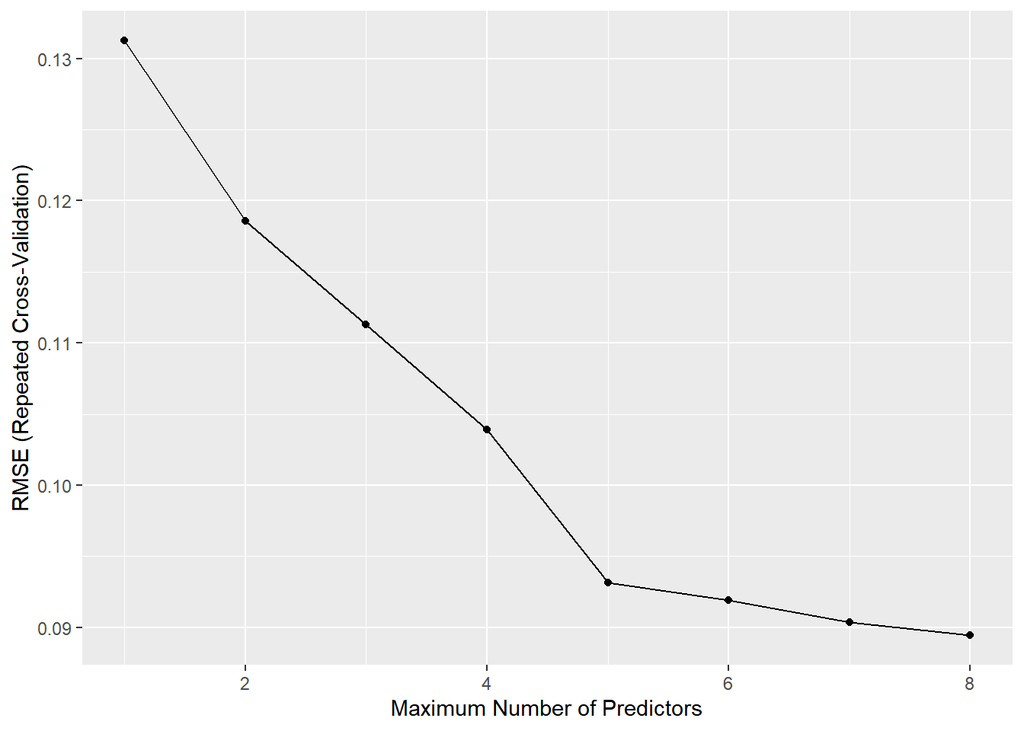

```r
#그래프 시각화
ggplot(bwd_model)
```

```r
#최적의 모델 coeff값
coef_bwd_cv <- coef(bwd_model$finalModel, 8)
#testset RMSE
test_pred_bwd <- predict(bwd_model, newdata=climate_test)
RMSE(test_pred_bwd, climate_test$Temp)
```

```
## [1] 0.1169519
```

```
(a)forward 방식과 backward방식 모두 8개의 feature을 bestmodel로 선정하였다. 하지만 8개를 구성하는 feature에는 차이를 보인다. forward 방식에는 MEI:CFC.12와 N2O:TSI가 있지만 backwarkd방식에는 없는 등 차이가 존재한다.
(b) test set에 대한 RMSE는 fwd_model이 더 낮지만 cross validated RMSE는 bwd_model이 더 낮다. 그렇기 때문에 backward 방식을 통해 선택된 모델이 best model이며 TSI/MEI:CFC.12/ CO2:N2O/N2O:TSI/CFC.11:TSI/CFC.11:Aerosols/CFC.12:TSI/CFC.12:Aerosols 가 feature를 구성하고 있다.
```

#### 1-6. 2, 3, 4, 5번에서 수립된 4개의 모델에 대해서 test set (2004년 이후 데이터)에 대한 prediction accuracy(RMSE)를 비교해 보자. 예상한 대로 결과가 나오는가? 그렇지 않다면 그 원인은 무엇일지 분석해보자.

[output not shown]

##2. Regression on Simulated Data

####2-1. feature 변수들과 target 변수 사이의 상관관계를 시각화해보자.

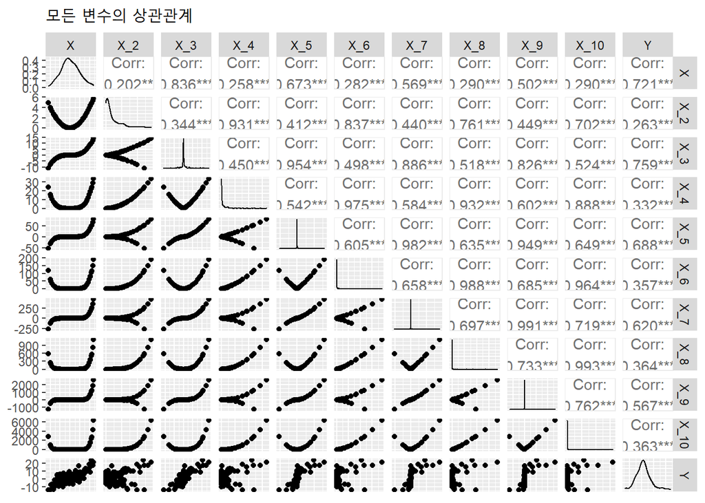

```r
#X, Y, E표본공간 생성
set.seed(123)
E = rnorm(200, mean=0, sd=4)
set.seed(1)
X = rnorm(200, mean=0, sd=1)
X_2 = X*X ; X_3=X*X*X; X_4=X*X*X*X; X_5=X*X*X*X*X; X_6=X*X*X*X*X*X;X_7=X*X*X*X*X*X*X;X_8=X*X*X*X*X*X*X*X;X_9=X*X*X*X*X*X*X*X*X;X_10=X*X*X*X*X*X*X*X*X*X;
Y=1+2*X-3*X_3+4*X_3+E
data = data.frame(X,X_2,X_3,X_4,X_5,X_6,X_7,X_8,X_9,X_10,Y)
#변수 사이의 상관관계 시각화(x축의 값지움_그래프 해석에 혼란을 야기)
ggpairs(data[c(1:11)],title="모든 변수의 상관관계")+theme(axis.title.x=element_blank(),axis.text.x=element_blank(),axis.ticks.x=element_blank())
```

####2-2. 10개의 feature를 모두 포함하는 linear regression model을 만들어보자. 통계적으로 유의한 변수가있는가? regression coefficient 값을 실제 값과 비교해보자.

```r
# 10개의 feature를 모두 포함하는 모델 생성
modelc=lm(Y~.,data=data)
summary(modelc)
```

```
##
## Call:
## lm(formula = Y ~ ., data = data)
##
## Residuals:
##     Min      1Q  Median      3Q     Max
## -8.6380 -2.3029 -0.3811  2.5570 13.9708
##
## Coefficients:
##             Estimate Std. Error t value Pr(>|t|)
## (Intercept)  1.45492    0.54959   2.647   0.0088 **
## X            3.71130    1.61238   2.302   0.0224 *
## X_2         -5.08299    3.52493  -1.442   0.1510
## X_3         -4.46568    4.40589  -1.014   0.3121
## X_4          7.26693    5.60119   1.297   0.1961
## X_5          4.16873    3.50140   1.191   0.2353
## X_6         -3.68049    3.30630  -1.113   0.2670
## X_7         -1.10166    1.03137  -1.068   0.2868
## X_8          0.78493    0.80042   0.981   0.3280
## X_9          0.09512    0.10024   0.949   0.3439
## X_10        -0.05969    0.06757  -0.883   0.3781
## ---
## Signif. codes:  0 '***' 0.001 '**' 0.01 '*' 0.05 '.' 0.1 ' ' 1
##
## Residual standard error: 3.813 on 189 degrees of freedom
## Multiple R-squared:  0.6107, Adjusted R-squared:  0.5901
## F-statistic: 29.65 on 10 and 189 DF,  p-value: < 2.2e-16
```

```
- 5%를 기준으로 p-value를 만족하는 feature은 X 한 개 존재한다.
- X의 coefficient값은 3.71130로 실제 값 2와 차이가존재한다.
```

####2-3. X,X_2,X_3 3개 변수를 feature로, 를 target으로 linear regression model을 만들어보자. 모든 feature들이 통계적으로 유의한가? regression coefficient 값을 실제 값과 비교해보자.

```r
#3개의 feature를 포함하는 변수 생성
modeld=lm(Y~X+X_2+X_3, data=data)
summary(modeld)
```

```
##
## Call:
## lm(formula = Y ~ X + X_2 + X_3, data = data)
##
## Residuals:
##     Min      1Q  Median      3Q     Max
## -9.1523 -2.3985 -0.3025  2.2955 13.0447
##
## Coefficients:
##             Estimate Std. Error t value Pr(>|t|)
## (Intercept)   0.8048     0.3369   2.389 0.017856 *
## X             1.9015     0.5331   3.566 0.000455 ***
## X_2           0.1594     0.2494   0.639 0.523382
## X_3           1.1103     0.1924   5.771 3.04e-08 ***
## ---
## Signif. codes:  0 '***' 0.001 '**' 0.01 '*' 0.05 '.' 0.1 ' ' 1
##
## Residual standard error: 3.786 on 196 degrees of freedom
## Multiple R-squared:  0.602,  Adjusted R-squared:  0.5959
## F-statistic: 98.83 on 3 and 196 DF,  p-value: < 2.2e-16
```

[output not shown]

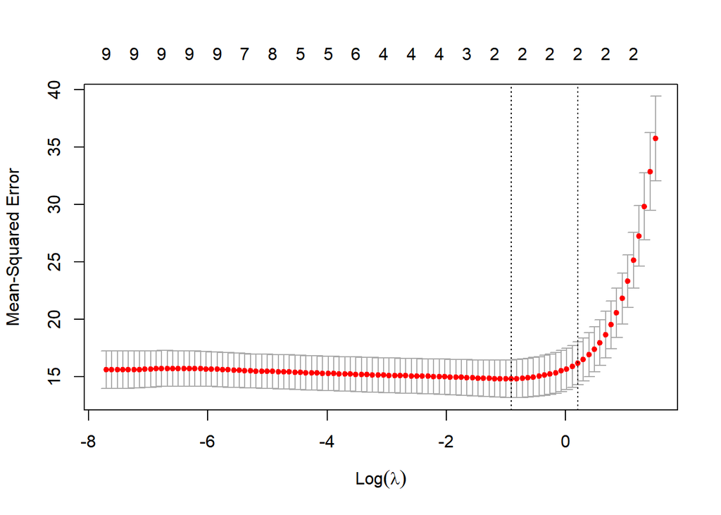

```r
#lasso를 수행하기 위한 변수 생성
X_lasso = model.matrix(Y ~., data)[,-1]
Y_lasso = data$Y
#10 fold cv 수행
set.seed(123)
cv_lasso = cv.glmnet(x=X_lasso, y=Y_lasso, alpha=1, nfolds=10)
#lambda 시각화
plot(cv_lasso)
```

```r
#best lambda와 coefficient 값 도출
best_lambda_lasso = cv_lasso$lambda.min
best_lambda_lasso
```

```
## [1] 0.4014574
```

```r
predict(cv_lasso, s = best_lambda_lasso, type = "coefficients")[1:11,]
```

```
## (Intercept)           X         X_2         X_3         X_4         X_5
##   0.9626992   1.6118517   0.0000000   1.0678329   0.0000000   0.0000000
##         X_6         X_7         X_8         X_9        X_10
##   0.0000000   0.0000000   0.0000000   0.0000000   0.0000000
```

[output not shown]